# Software Engineering Principles

3rd ORMIR Workshop, Calgary, July 8, 2026

Christof Seiler

University Hospital and University of Zurich

## Goal of Software Engineering

Write code that is  
**safe** from bugs,  
ready for **change**, and  
easy to **understand**

## My Plan for Today

- Part 1: What is Software Engineering?  
  ⏳ *20 minutes*
- Part 2: Unit Tests  
  ⏳ *20 minutes*
- Part 3: Unit Tests in Python  
  ⏳ *20 minutes*

# Part 1: What is Software Engineering?

## Pentium Example

[figure not shown]

Source: [wikimedia](https://commons.wikimedia.org/wiki/File:KL_Intel_Pentium_A80501.jpg)

**Pentium division bug**

- 1 in 9 billion divisions were affected
- Thomas Nicely (a math professor) found it while computing with prime numbers
- The results didn’t agree with theory

## Ariane 5 Example

[figure not shown]

**European Space Agency**

- In the 1990s, self-destructed 37 seconds after its first launch
- The Ariane 5’s guidance software was reused from the Ariane 4

Source: [wikimedia](https://commons.wikimedia.org/wiki/File:Ariane_501_Cluster.svg)

## Ariane 5 Example

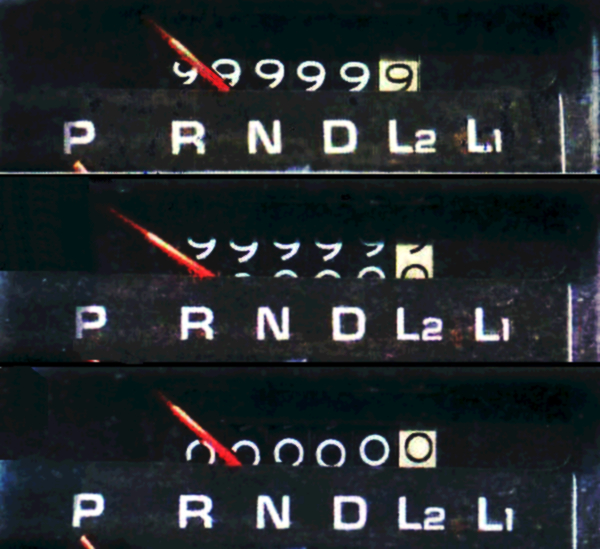

Source: [wikipedia](https://nl.wikipedia.org/wiki/Bestand:Odometer_rollover.jpg)

- **Overflow**: Velocity calculation converted from double (64 bits) to short (16 bits)
- Exception handler had been disabled for **efficiency** reasons
- The cost of the failure was $1 billion

## Hacking vs. Engineering

**Hacking**

🙈 writing lots of code before **testing** any of it  
🙈 keeping all the details in your **head**  
🙈 assuming that **bugs** won’t exist

**Software engineering**

😎 write a little bit at a time, **testing as you go**  
😎 **document** your assumptions  
😎 **defend your code** against yourself

## Topics in Software Engineering

- Testing and linting *(unit tests, today)*
- Debugging *(coverage, today)*
- Version control *(GitHub)*
- Code review *(GitHub pull request)*
- Continuous integration *(GitHub actions)*
- Refactoring
- Design patterns

# Part 2: Unit Tests

## Validation

*Testing* ⊂ *validation* and includes:

- **Verification**: Formal proof that a program is correct
- **Code review**: Somebody else reads your code
- **Testing**: Run on selected inputs and check results

## Some Stats

| Quality Level | Defects / *kloc* | Example |
| --- | --- | --- |
| typical industry software | 1–10 | most commercial software |
| high-quality validation | 0.1–1 | Java libraries |
| safety-critical validation | 0.01–0.1 | NASA |

- *kloc*: one thousand lines of source code

## Why Are There So Many Bugs?

- **Exhaustive testing** not possible: too many test cases
- **Example**: multiply two numbers `a x b`

## Why Are There So Many Bugs?

- 1-bit numbers:

| `a × b` | **b = 0** | **b = 1** |
| --- | --- | --- |
| **a = 0** | 0 | 0 |
| **a = 1** | 0 | 1 |

## Why Are There So Many Bugs?

- 2-bit numbers:

| `a × b` | **b = 0** | **b = 1** | **b = 2** | **b = 3** |
| --- | --- | --- | --- | --- |
| **a = 0** | 0 | 0 | 0 | 0 |
| **a = 1** | 0 | 1 | 2 | 3 |
| **a = 2** | 0 | 2 | 4 | 6 |
| **a = 3** | 0 | 3 | 6 | 9 |

## Why Are There So Many Bugs?

- 3-bit numbers:

| `a × b` | **b = 0** | **b = 1** | **b = 2** | **b = 3** | **b = 4** | **b = 5** | **b = 6** | **b = 7** |
| --- | --- | --- | --- | --- | --- | --- | --- | --- |
| **a = 0** | 0 | 0 | 0 | 0 | 0 | 0 | 0 | 0 |
| **a = 1** | 0 | 1 | 2 | 3 | 4 | 5 | 6 | 7 |
| **a = 2** | 0 | 2 | 4 | 6 | 8 | 10 | 12 | 14 |
| **a = 3** | 0 | 3 | 6 | 9 | 12 | 15 | 18 | 21 |
| **a = 4** | 0 | 4 | 8 | 12 | 16 | 20 | 24 | 28 |
| **a = 5** | 0 | 5 | 10 | 15 | 20 | 25 | 30 | 35 |
| **a = 6** | 0 | 6 | 12 | 18 | 24 | 30 | 36 | 42 |
| **a = 7** | 0 | 7 | 14 | 21 | 28 | 35 | 42 | 49 |

## Why Are There So Many Bugs?

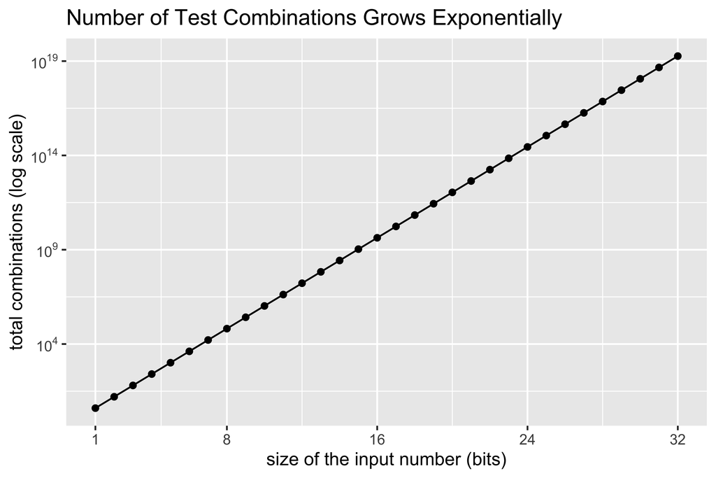

## Some Ideas

**Haphazard testing** (or “just try it and see if it works”)

- Not likely to find bugs
- Only works if program is very buggy

## Some Ideas

**Random or statistical testing**

- Other engineering disciplines:
  - test 1% of hard drives and infer the defect rate
  - open fridge 1000 times in 24 hours
- Doesn’t work well for software:
  - **discontinuous** and **discrete** across the input space

## Putting on Your Testing Hat

When you’re **coding**:

- your goal is to make the program **work**

When you’re **testing**:

- you want to make it **fail**

## Test-First Programming

1. *Specification*
2. **Tests**
3. **Actual code**

```python
def classify(x: float) -> str:
    """
    Classify a number as positive, zero, or negative.

    Parameters
    ----------
    x : float
        The number to classify.

    Returns
    -------
    str
        - ``"positive"`` if x > 0
        - ``"zero"``     if x == 0
        - ``"negative"`` if x < 0

    Examples
    --------
    >>> classify(1)
    'positive'
    >>> classify(0)
    'zero'
    >>> classify(-3)
    'negative'
    >>> classify(float('inf'))
    'positive'
    >>> classify(float('-inf'))
    'negative'
    """
```

## Choosing Test Cases by Partitioning

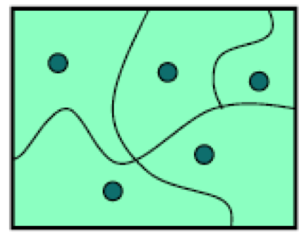

- Trade-off:
  - test cases that are **small and fast**
  - test cases that are **large enough** to validate the program
- Divide the input space into *subdomains*
- Choose one *test case* from each subdomain

## Example: `max(a, b)`

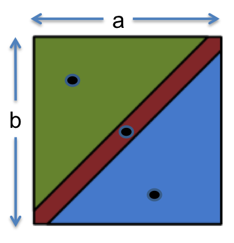

| Partition | Test case `(a, b)` | Expected `max(a, b)` |
| --- | --- | --- |
| $a < b$ | $(1, 2)$ | $2$ |
| $a = b$ | $(9, 9)$ | $9$ |
| $a > b$ | $(-5, -6)$ | $-5$ |

## Include Boundaries in the Partition

| Boundary type | Example | Why bugs happen |
| --- | --- | --- |
| zero | `0` between positive and negative | off-by-one: `<= 0` instead of `< 0` |
| numeric limits | `sys.float_info.max`, `sys.float_info.min` | overflow to `inf` |

## Include Boundaries in the Partition

| Boundary type | Example | Why bugs happen |
| --- | --- | --- |
| empty collection | `""`, `[]`, `np.array([])` | special case: empty often skips loops or breaks indexing |
| first/last element | `list[0]`, `list[-1]` | off-by-one: `<` vs `<=`, counter starting at `0` vs `1` |

## Example: `max(a, b)`

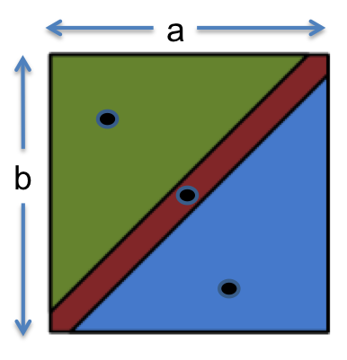

[output not shown]

## Covering the Partition

| Strategy | Description | Example coverage |
| --- | --- | --- |
| *full Cartesian product* | every legal combination of all partition dimensions | 5 parts × 5 parts = 25 test cases |
| *cover each part* | every part of each dimension covered at least once | 5 parts × 5 parts → as few as 5 test cases |

## Covering the Partition

| Strategy | Description | Example coverage |
| --- | --- | --- |
| *compromise* | guided by human judgement, caution, and code coverage tools | somewhere in between |

## Coverage Reports

Three common kinds of coverage:

- *Statement coverage*: is every statement run by some test case?
- *Branch coverage*: for every `if` or `while` statement in the program, are both the true and the false direction taken by some test case?
- *Path coverage*: is every possible combination of branches—every path through the program—taken by some test case?

## Black Box and Glass Box Testing

*Black box testing*

- test cases only from the **specification**
- partitioned without looking at the actual code
- examples: our previous approach to test `multiply` and `max`

*Glass box testing*

- test cases from actual **implementation**
- example: implementation selects **different algorithms depending** on the **input**

## Automated Testing

[figure not shown]

Source: [xkcd](https://xkcd.com/1739/)

- *Regressing*: introducing other bugs when you fix new bugs or add new features
- *Regression testing*: running all your tests after every change

## Automated Testing

**Test-first debugging**:

1. Bug arises
2. Write a test case for it that elicits it
3. Add it to your test suite

# Part 3: Unit Tests in Python

Module `mymodule.py`:

```python
def classify(x: float) -> str:
    """Classify a number as positive, zero, or negative."""
    if x > 0:
        return "positive"
    elif x == 0:
        return "zero"
    else:
        return "negative"
```

Unit test `test_mymodule.py`:

```python
from mymodule import classify

def test_positive():
    assert classify(1) == "positive"

def test_zero():
    assert classify(0) == "zero"

# test_negative is missing on purpose!
```

On the terminal:

```bash
pip install pytest pytest-cov
pytest test_mymodule.py --cov=mymodule --cov-report=html
```

Background:

| Part | Meaning |
| --- | --- |
| `pytest` | run the test suite |
| `test_mymodule.py` | only run tests in this file |
| `--cov=mymodule` | measure coverage of `mymodule.py` |
| `--cov-report=html` | write report as HTML in `htmlcov/` |

## Summary

Tasks:

- Write tests **before** you write code
- Choose test cases systematically by **partitioning**
- Test each each module with unit test in **isolation**

Tools:

- Use **glass box testing** and **coverage** for your test suite
- Use **automated testing** to keep bugs away

## Thanks for Listening!

Material based on this course:

- MIT 6.031 Software Construction
- Course website: https://web.mit.edu/6.031